# Cyclistic Bike-Share

Anh Tran

## 1. Introduction

Cyclistic, a bike-share company in Chicago, features more than 5,800 bikes and 600 docking station. They offer both classic bike and electric bike. There are two options for bike users: casual and member. The company aims to improve their earnings by reaching out to their casual riders.

In this study, R has been used to analyse the datasets of the company for the year of 2020. All the data including member type, bike type, time, duration of ride, to name a few are collected. Analyzing all those data will help the Company to better understanding how casual and member rider use Cylistic bikes differently depending on the season of the year or the location.

## 2. Collecting Data

Cylistic’s historical trip data of 12 months in 2020 were downloaded from [here](https://divvy-tripdata.s3.amazonaws.com/index.html). All the .csv files were unzip and stored in working directory

## 3. Wrangling Data

#### 3.1 Setting up environment

- tidyverse for data import, wrangling, and for visualization
- libridate for date functions
- geosphere, ggmap for geography

#### 3.2 Importing Data

- Import all dataset one by one for 12 months in 2020 using function **read.csv()**. For example: m1 <- read.csv(“202001-divvy-tripdata.csv”)

#### 3.3 Cleaning Data

- Check datatype of all columns using **str()** to ensure the consistence between datasets. For example, start_station_id and end_station_id are integer in some files but are character in others. Thus, those columns in several files have been changed from integer type to character type using **as.character()** function to ensure consistence in the whole dataset.
- Merge all the files to the final one for analysis using **bind_rows()** function. The dataset includes 3,541,683 rows and 13 columns

```
## 'data.frame':    3541683 obs. of  13 variables:
##  $ ride_id           : chr  "EACB19130B0CDA4A" "8FED874C809DC021" "789F3C21E472CA96" "C9A388DAC6ABF313" ...
##  $ rideable_type     : chr  "docked_bike" "docked_bike" "docked_bike" "docked_bike" ...
##  $ started_at        : chr  "2020-01-21 20:06:59" "2020-01-30 14:22:39" "2020-01-09 19:29:26" "2020-01-06 16:17:07" ...
##  $ ended_at          : chr  "2020-01-21 20:14:30" "2020-01-30 14:26:22" "2020-01-09 19:32:17" "2020-01-06 16:25:56" ...
##  $ start_station_name: chr  "Western Ave & Leland Ave" "Clark St & Montrose Ave" "Broadway & Belmont Ave" "Clark St & Randolph St" ...
##  $ start_station_id  : chr  "239" "234" "296" "51" ...
##  $ end_station_name  : chr  "Clark St & Leland Ave" "Southport Ave & Irving Park Rd" "Wilton Ave & Belmont Ave" "Fairbanks Ct & Grand Ave" ...
##  $ end_station_id    : chr  "326" "318" "117" "24" ...
##  $ start_lat         : num  42 42 41.9 41.9 41.9 ...
##  $ start_lng         : num  -87.7 -87.7 -87.6 -87.6 -87.6 ...
##  $ end_lat           : num  42 42 41.9 41.9 41.9 ...
##  $ end_lng           : num  -87.7 -87.7 -87.7 -87.6 -87.6 ...
##  $ member_casual     : chr  "member" "member" "member" "member" ...
```

- Check if any NA values in impotant columm, for example in **ride_id** column

```
##            ride_id      rideable_type         started_at           ended_at
##                  0                  0                  0                  0
## start_station_name   start_station_id   end_station_name     end_station_id
##                  0              83583                  0              98105
##          start_lat          start_lng            end_lat            end_lng
##                  0                  0               4255               4255
##      member_casual
##                  0
```

- Format **date** datatype to suitable data format. Split the **started_at** to Year, Monh, Date and Day columns

#### 3.4. Calculating ride_length

- Add a “ride_length” calculation to **all_trips** dataset (in seconds). Further checking whether this datatype is numeric. Otherwise, conversion to numeric is needed. All the calculations are then converted to minutes.

```r
all_trips$ride_length <- difftime(all_trips$ended_at,all_trips$started_at)
is.numeric(all_trips$ride_length)
```

```
## [1] FALSE
```

```r
all_trips$ride_length <- as.numeric(as.character(all_trips$ride_length))
is.numeric(all_trips$ride_length)
```

```
## [1] TRUE
```

```r
all_trips$ride_length <- all_trips$ride_length/60
```

- The dataset is finally check for any negative value of ride_length which is calculated as above. All the negative values are removed. The dataset is now ready for analysis.

```r
all_trips_v2 <- all_trips[!(all_trips$start_station_name == "HQ QR" | all_trips$ride_length<=0),]
```

#### 3.5 Calculate the distance and speed

- Distance of traveling is obtained using the longitude and latitude of the start and end station. From the distance, speed is calculate.

```r
all_trips_v2$ride_length <- difftime(all_trips_v2$ended_at,all_trips_v2$started_at)
all_trips_v2$ride_distance <- distGeo(matrix(c(all_trips_v2$start_lng, all_trips_v2$start_lat), ncol = 2), matrix(c(all_trips_v2$end_lng, all_trips_v2$end_lat), ncol = 2))
all_trips_v2$ride_distance <- all_trips_v2$ride_distance/1000
all_trips_v2$ride_speed = c(all_trips_v2$ride_distance)/as.numeric(c(all_trips_v2$ride_length), units="hours")
```

## 4. Conducting Descriptive Anaysis

```
##   Length    Class     Mode
##  3527000 difftime  numeric
```

- Summary on the data of **membership** and **bike** types with the frequency. From these attributes, all analysis will be based on **Member**, **Casual**, **Classic Bike**, **Docked Bike** and **Electric Bike**
- Member involves in 61% whereas Casual is 39%

```
##
##  casual  member
## 1366575 2175108
```

```
##
##  classic_bike   docked_bike electric_bike
##         70616       2966322        504745
```

#### 4.1 Correlation between number of **Rides per Day** and User Type of **Casual** or **Member**

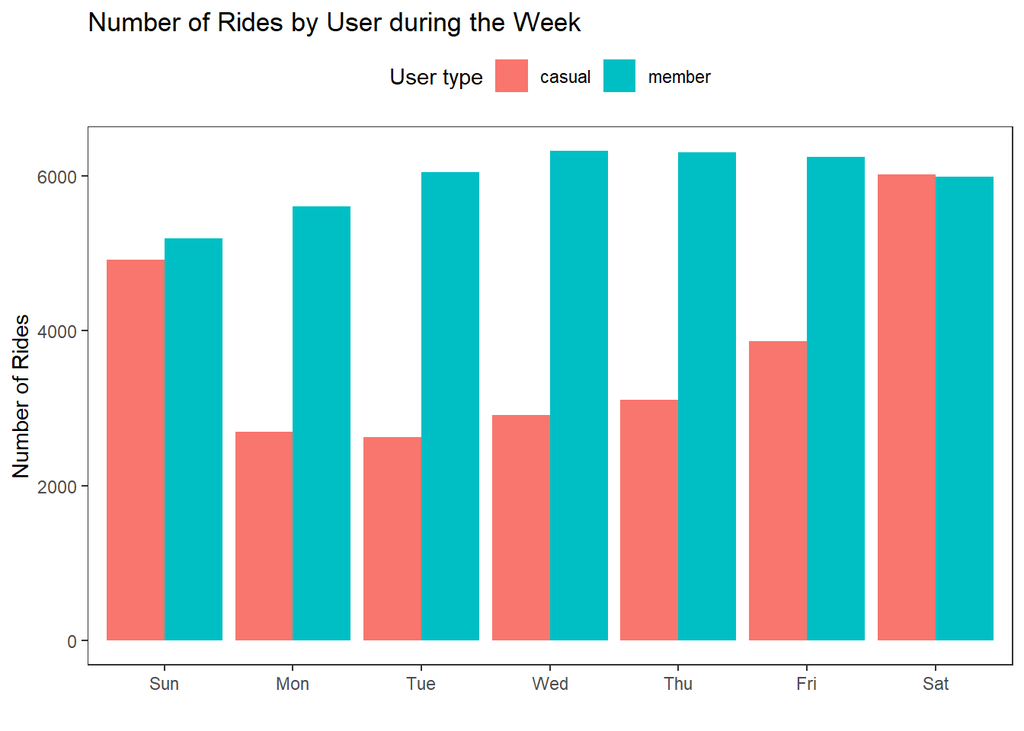

#### 4.2 Correlation between **Mean Travel Time** and User Type of **Casual** or **Member**

- The number of users per day of Member is significantly higher than that of Casual rider. However, the duration of ride per day of Casual rider (about 45 minutes/day) is over two times the time Member rides spend on the bike.

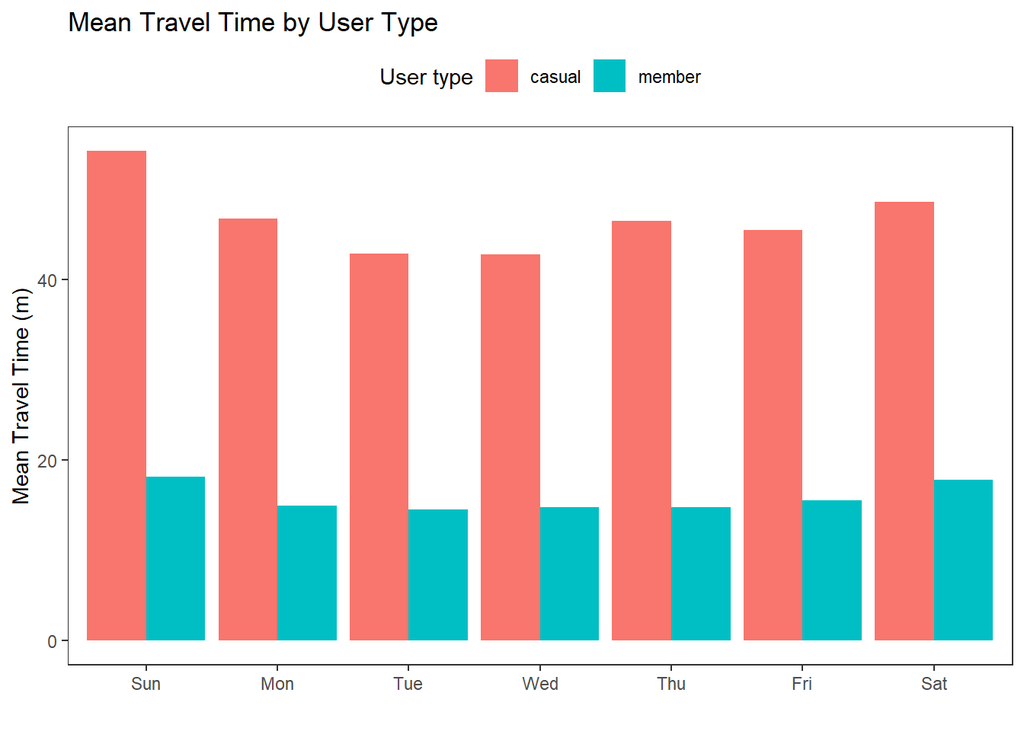

#### 4.3 Correlation between **Mean Travel Time** and Customer Type of **Casual** or **Member** as a function of Month

[figure not shown]

#### 4.4 Correlation between number of **Rides** and User Type of **Casual** or **Member** by Month

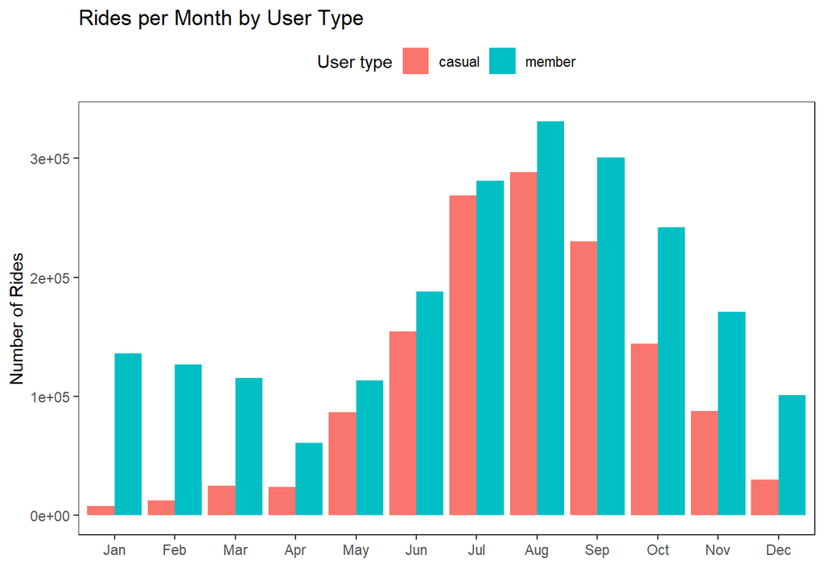

#### 4.5 Top 20 busiest station in number of rides

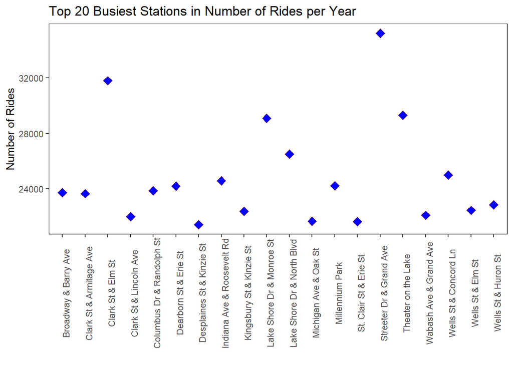

#### 4.6 Bottom 20 least busy station in number of rides

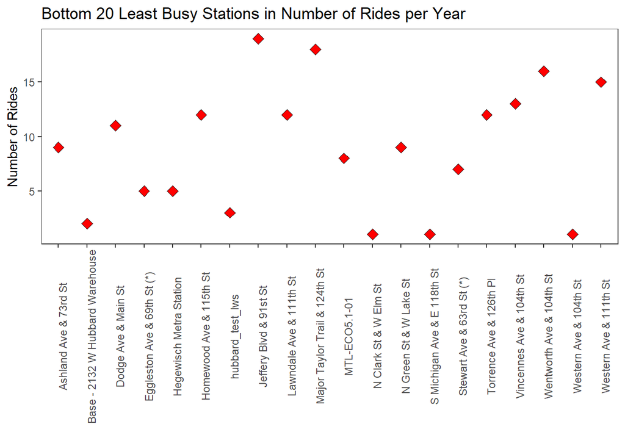

#### 4.7 Top 20 station with highest travel time

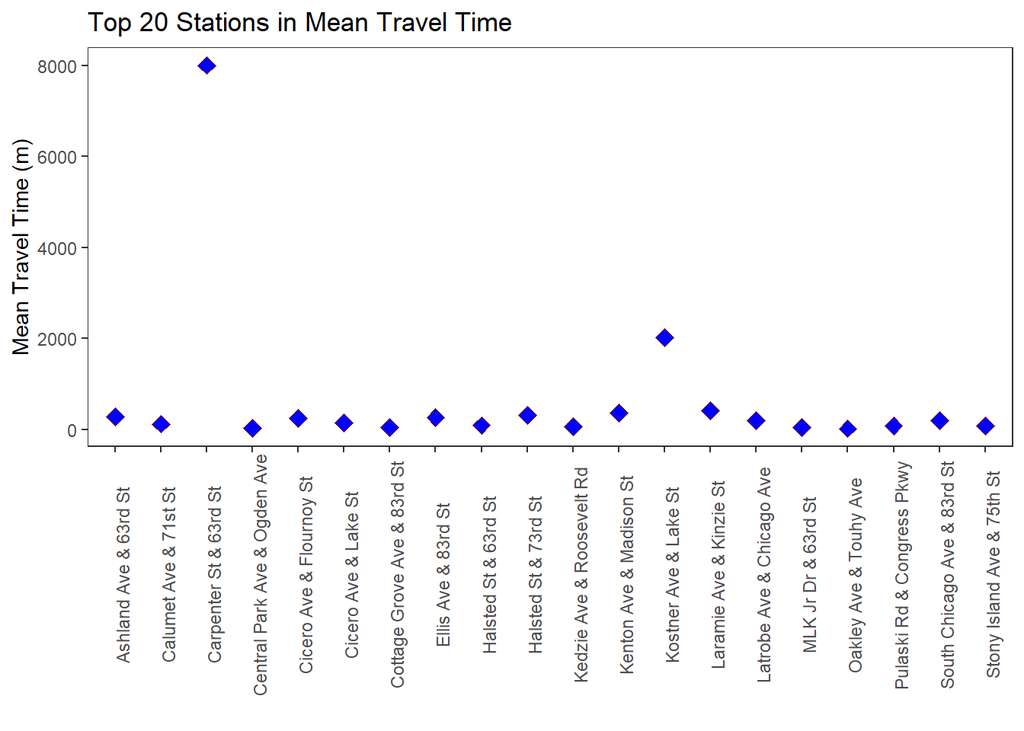

#### 4.8 Map of User Type

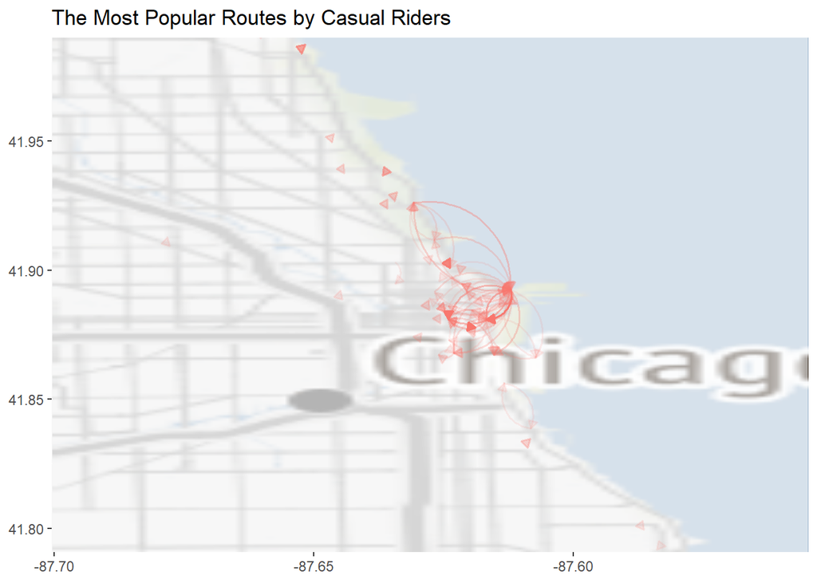

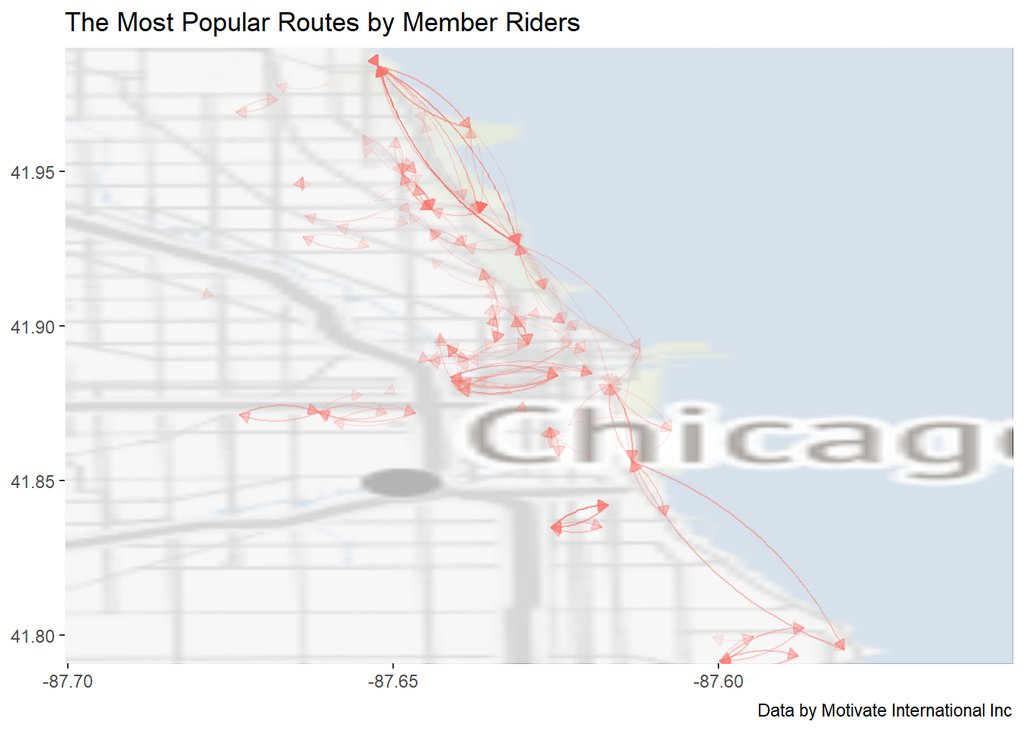

#### 4.9 Correlation between **Bike Type Usage** and **User Type**

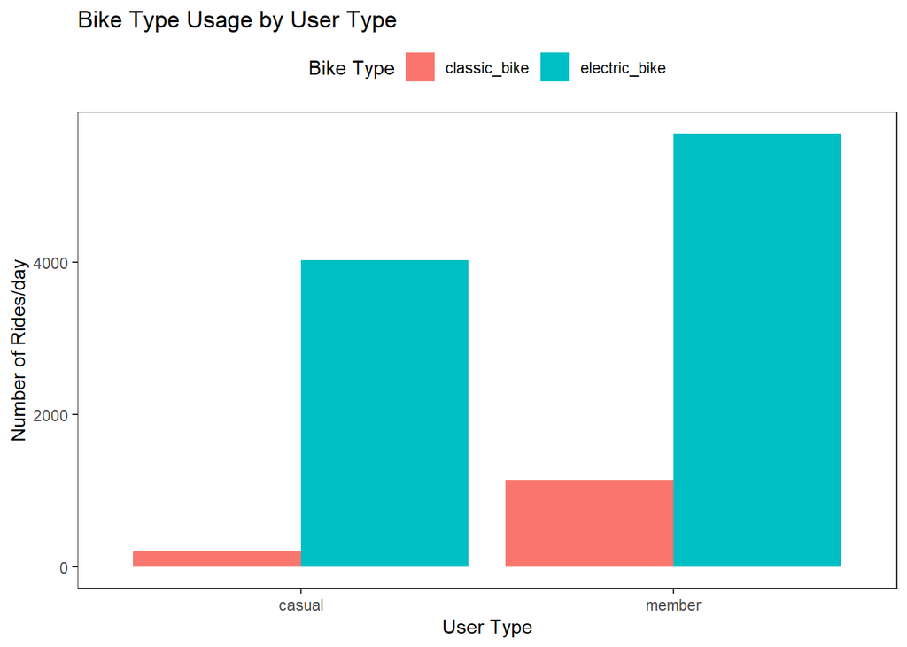

#### 4.10 Bike type usage by user during the week

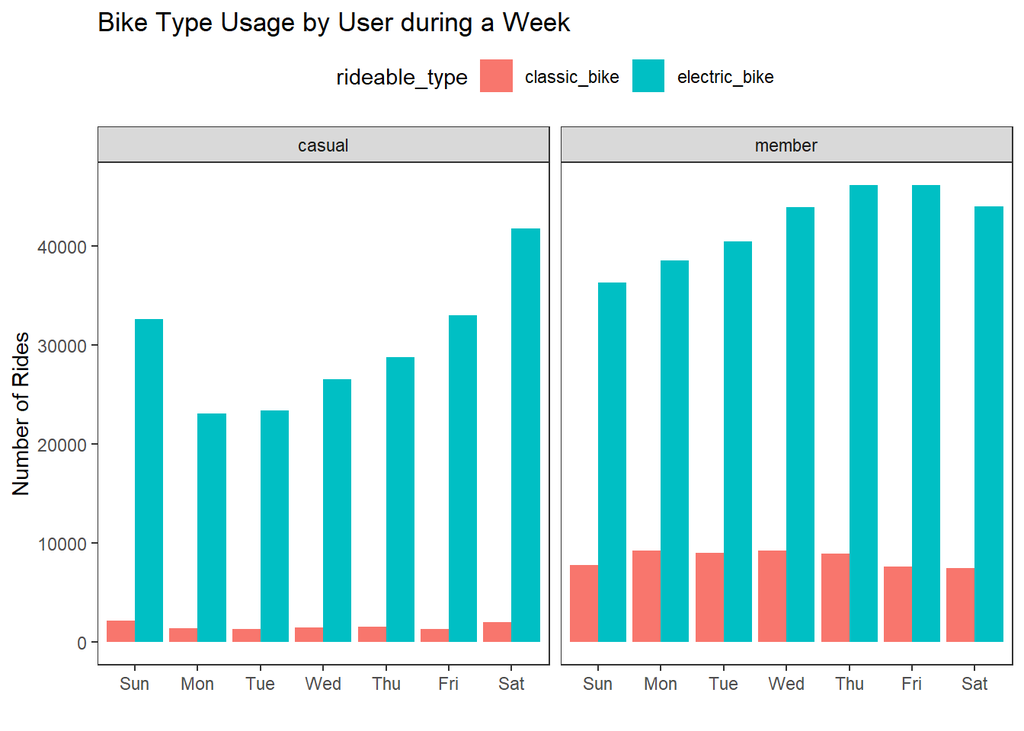

## 5. Conclusions

The dataset of bike riders in 2020 of Cylistic company has been analysed using R. Significant insight into the data has been gained as belows: - The usage of both casual and member riders change with bike type, time and location. - Higher casual users are during the weekend with electric bikes.

From all these results, suitable marketing is required to enhance the usage of casual rider as well as proper preparation to make sure that bike is always available at the busiest stations.